# Introduction to Jupyter Notebooks

This notebook is composed of many *chunks*, containing either python code or formatted text. In this activity you will practice both. Make sure to always run each code chunk once as you work past it.

*Get in a group of 3-4 people. You should each fill out your own copy of this notebook.*

1. Write the names of your group members below, as a bullet point list.
- Miranda
- Sarah
- Paige
- Melissa
- Ashley
2. Find something that all of you enjoy for fun. Insert a related picture or meme below.

Our group enjoys going to the beach, my favorite beach in SLO is Morro bay or Avila.

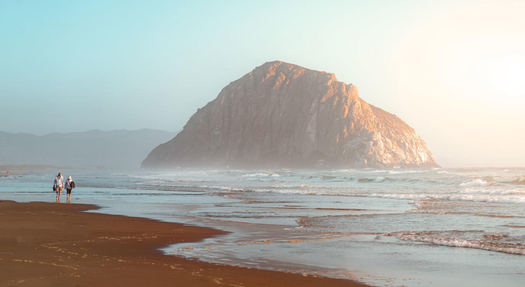

3. Everyone decide your comfort level on a scale of 1-10 in python, and your favorite colors from [this](https://matplotlib.org/stable/gallery/color/named_colors.html) list.

Edit the code below so that it has your names and corresponding comfort levels.

```python
#EXAMPLE OF WHAT IS TYPED BELOW IN CODE BOX
group_data = {
  'names': ["Person 1", "Person 2", "Person 3", "Person 4"],
  'colors': ["goldenrod", "goldenrod", "goldenrod", "goldenrod"],
  'comfort': [1, 3, 10, 5]
  }
```

```python
group_data = {
  'names': ["Miranda", "Sarah", "Paige", "Melissa", "Ashley"],
  'colors': ["lightseagreen", "tab:pink", "teal", "orange","lavender"],
  'comfort': [1, 1, 1, 1, 1]
  }
```

4. Click “Run” on the code chunk below and see the plot that is produced.

(Do not edit the code below!)

```python
plt.bar(x = group_data['names'], height = group_data['comfort'], color = group_data['colors'])
plt.ylabel("Comfort with python")
plt.show()
```

[figure not shown]

Our comfort levels with python